# 3. час: Боје и приказивање низова података

На овом часу ћеш научити:

1. још један начин да премешташ ћелије унутар Џупајтер радне свеске;
2. како да приказујеш графиконе у разним бојама; и
3. како да приказујеш податке хистограмима.

## 3.1. Још мало о Џупајтер радној свесци

Већ смо неколико пута рекли да се Џупајтер радна свеска састоји из низа ћелија, а свака ћелија може да садржи текст, математички израз или низ Пајтон наредби. Низ дугмића при врху стране ти омогућује да бараташ ћелијама Џупајтер радне свеске на разне начине. До сада смо упознали

- дугме **Run** које извршава ћелију,
- дугме које личи на дискету помоћу кога можемо да снимимо радну свеску,
- дугме са знаком **+** које додаје нову ћелију испод активне ћелије и
- стрелице на горе и на доле које померају радну ћелију за једно место горе или доле.

Следећа три дугмета:

[figure not shown]

омогућују да се са ћелијама обављају стандардне операције које се на енглеском зову *cut* (исеци, дугме "маказе"), *copy* (ископирај, дугме "два листа папира") и *paste* (залепи, дугме "лист папира који се додаје на радну подлогу").

Ако желиш **да преместиш неку ћелију:**

1. кликни на ту ћелију,
2. кликни на дугме *cut* (дугме "маказе"),
3. кликни на неко друго место у Џупајтер радној свесци, и
4. кликни на дугме *paste* (дугме "лист папира који се додаје на радну подлогу").

Ова операција се кратко зове *cut/paste*.

Ако желиш **да ископираш неку ћелију:**

1. кликни на ту ћелију,
2. кликни на дугме *copy* (дугме "два листа папира")
3. кликни на неко друго место у Џупајтер радној свесци, и
4. кликни на дугме *paste* (дугме "лист папира који се додаје на радну подлогу").

Ова операција се кратко зове *copy/paste*.

## 3.2. Боје на графиконима

Подсетимо се графикона са максималним и минималним температурама по месецима које су забележене у Сјеници у периоду 1981-2010. године. (Подаци су преузети са сајта Републичког хидрометеоролошког завода и доступни су на адреси http://www.hidmet.gov.rs/latin/meteorologija/stanica_sr.php?moss_id=13369).

Прво смо направили три низа података: списак имена месеци, списак на максималним температурама у наведеном периоду и списак са минималним температурама у наведеном периоду.

```python
meseci =               ["Јан", "Феб", "Мар", "Апр", "Мај", "Јун", "Јул", "Авг", "Сеп", "Окт", "Нов", "Дец"]
SjenicaMaxPoMesecima = [ 14.0,  19.4,  21.9,  24.3,  28.8,  31.5,  33.5,  32.8,  29.7,  26.5,  20.2,  18.0]
SjenicaMinPoMesecima = [-35.6, -31.0, -25.0,  -8.3,  -6.4,  -3.7,  -0.4,  -1.3,  -9.3, -10.7, -26.2, -29.6]
```

Потом смо увезли целу библиотеку за цртање графикона и дали јој скраћено име `plt`:

```python
import matplotlib.pyplot as plt
```

И на крају смо приказали ова два низа података: свака `plot` наредба је додала по један низ података на графикон, додали смо наслов графикона (функција `title`), ознаку на $y$-оси (функција `ylabel`) и приказали графикон (функција `show`). Функција `close` завршава рад на графикону:

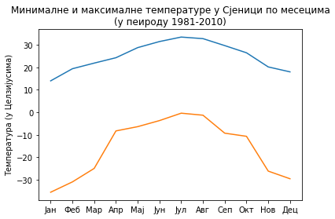

```python
plt.plot(meseci, SjenicaMaxPoMesecima)
plt.plot(meseci, SjenicaMinPoMesecima)
plt.title("Минималне и максималне температуре у Сјеници по месецима\n(у пеироду 1981-2010)")
plt.ylabel("Температура (у Целзијусима)")
plt.show()
plt.close()
```

Уколико желимо да графикон који приказује максималне температуре буде приказан црвеном бојом, а графикон који приказује минималне температуре плавом, можемо у функцији `plot` да додамо информацију о боји, овако:

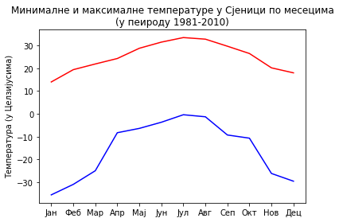

```python
plt.plot(meseci, SjenicaMaxPoMesecima, color = "r")
plt.plot(meseci, SjenicaMinPoMesecima, color = "b")
plt.title("Минималне и максималне температуре у Сјеници по месецима\n(у пеироду 1981-2010)")
plt.ylabel("Температура (у Целзијусима)")
plt.show()
plt.close()
```

Енглеска реч *color* значи "боја". Прва `plot` наредба исцртава график црвеном бојом ("r" = *red* = црвено), а друга плавом ("b" = *blue* = плаво). Можемо користити следеће боје:

| Слово | Боја (енг) | Боја (српски) |
| --- | --- | --- |
| "b" | blue | плава |
| "g" | green | зелена |
| "r" | red | црвена |
| "c" | cyan | светло плава |
| "m" | magenta | роза |
| "y" | yellow | жута |
| "k" | black | црна |
| "w" | white | бела |

## 3.3. Хистограми

У ситуацијама када података нема много, згодно их је приказати низом стубића. Такви дијаграми се зову *хистограми* или *стубичасти дијаграми* (на енглеском *bar charts*).

Претпоставимо да је на полугодишту један ученик имао следеће оцене из наведених предмета:

```python
predmeti = ["мат", "срп", "лик", "ист", "физ", "муз", "тио"]
ocene    = [2,     4,     5,     3,     5,     4,     5    ]
```

Ове податке можемо представити хистограмом позивом функције `bar` (зато што се ова врста дијаграма на енглеском зове *bar chart*):

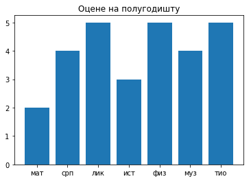

```python
plt.bar(predmeti, ocene)
plt.title("Оцене на полугодишту")
plt.show()
plt.close()
```

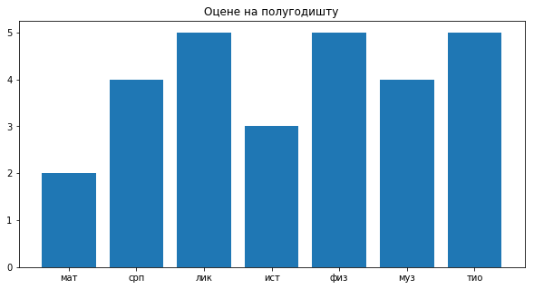

```python
plt.figure(figsize=(10,5))
plt.bar(predmeti, ocene)
plt.title("Оцене на полугодишту")
plt.show()
plt.close()
```

Могуће је на истом графикону једну групу података приказати линијом, а другу хистограмом, како је то показано у следећем примеру.

У наредној ћелији налазе се подаци о броју редовних корисника рачунара (у процентима) и броју редовних корисника интернета (у процентима) према старосним групама за 2006. годину. (Подаци су преузети са сајта Републичког завода за статистику (http://www.stat.gov.rs/).)

```python
starosneGrupe      = ["16-24", "25-34", "35-44", "45-54", "55-64", "65-74"]
korisniciRacunara  = [77.8,    43.6,    45.5,    34.8,    13.0,    3.5]
korisniciInterneta = [58.3,    35.4,    30.0,    22.0,    8.0,     2.3]
```

Приказаћемо ове податке на једном графикону тако што ћемо проценат корисника рачунара приказати зеленим стубићима, а проценат корисника интернета плавом линијом.

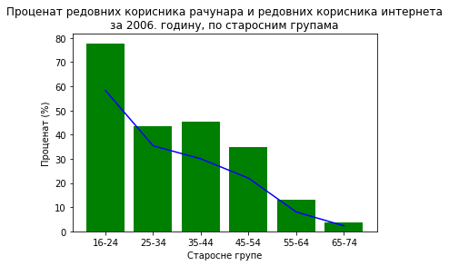

```python
plt.bar(starosneGrupe, korisniciRacunara, color = "g")
plt.plot(starosneGrupe, korisniciInterneta, color = "b")
plt.title("Проценат редовних корисника рачунара и редовних корисника интернета\nза 2006. годину, по старосним групама")
plt.xlabel("Старосне групе")
plt.ylabel("Проценат (%)")
plt.show()
plt.close()
```

Функције `xlabel` и `ylabel` додају појашњења ознака на $x$-оси, односно на $y$-оси.

За некога ко је само бацио поглед на дијаграм и није пажљиво читао текст пре њега није сасвим јасно који подаци су представљени зеленим стубићима, а који плавом линијом. Зато се дијаграму може додати легенда којом се дају додатна објашњења (шта је представљено плавом, а шта зеленом бојом).

Прво ћемо и команди `bar` и команди `plot` додати још по један параметар облика `label="објашњење"` који укратко описује податке приказане на том делу дијаграма. Функција `legend` потом црта легенду на дијаграму.

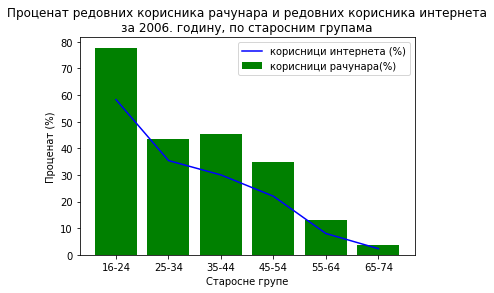

```python
plt.bar(starosneGrupe, korisniciRacunara, color = "g", label="корисници рачунара(%)")
plt.plot(starosneGrupe, korisniciInterneta, color = "b", label="корисници интернета (%)")
plt.title("Проценат редовних корисника рачунара и редовних корисника интернета\nза 2006. годину, по старосним групама")
plt.xlabel("Старосне групе")
plt.ylabel("Проценат (%)")
plt.legend()
plt.show()
plt.close()
```

## 3.4. Задаци

Задатке реши у Џупајтеру.

**Задатак 1.**

*(а)* Шта ће се десити ако у последњем примеру командама `plot` и `bar` замениш место? Пробај да претпоставиш шта је одговор имајући у виду да Пајтон црта објекте оним редом којим наилази на команде за цртање.

*(б)* Да ли је редослед навођења команди битан приликом креирања дијаграма?

**Задатак 2.** Прикажи хистограмом своје оцене на полугодишту (или на крају прошле године).

**Задатак 3.** У следећој табели су приказане највише и најниже температуре (у Целзијусима) икада измерене на континентима:

| Континент: | Европа | Азија | Африка | Северна Америка | Јужна Америка | Аустралија | Антарктик |
| --- | --- | --- | --- | --- | --- | --- | --- |
| Највиша забележена темп: | 48 | 54 | 55 | 56.7 | 48.9 | 50.7 | 19.8 |
| Најнижа забележена темп: | -58.1 | -67.8 | -23.9 | -63 | -32.8 | -23 | -89.2 |

Прикажи оба низа података хистограмима на истом графикону. Нека максималне температуре буду представљене црвеним стубићима, а минималне плавим. (Подаци су преузети са странице https://www.space.com/17816-earth-temperature.html)

**Задатак 4.**

*(а)* Пронађи на Интернету шта ради функција `barh` из библиотеке `matplotlib`.

*(б)* Ако у решењу претходног задатка уместо функције `bar` употребиш функцију `barh` на оба места, какав ћеш графикон добити?